# Student Exam score prediction

## Import Libraries

```python
import pandas as pd
import numpy as np
import matplotlib.pyplot as plt
import seaborn as sns
%matplotlib inline
```

### Let's start by reading in the student-mat.csv file into a pandas dataframe.

```python
student= pd.read_csv('student-mat.csv')
```

```python
student
```

|  | school | sex | age | address | famsize | Pstatus | Medu | Fedu | Mjob | Fjob | ... | famrel | freetime | goout | Dalc | Walc | health | absences | G1 | G2 | G3 |
| --- | --- | --- | --- | --- | --- | --- | --- | --- | --- | --- | --- | --- | --- | --- | --- | --- | --- | --- | --- | --- | --- |
| 0 | GP | F | 18 | U | GT3 | A | 4 | 4 | at_home | teacher | ... | 4 | 3 | 4 | 1 | 1 | 3 | 6 | 5 | 6 | 6 |
| 1 | GP | F | 17 | U | GT3 | T | 1 | 1 | at_home | other | ... | 5 | 3 | 3 | 1 | 1 | 3 | 4 | 5 | 5 | 6 |
| 2 | GP | F | 15 | U | LE3 | T | 1 | 1 | at_home | other | ... | 4 | 3 | 2 | 2 | 3 | 3 | 10 | 7 | 8 | 10 |
| 3 | GP | F | 15 | U | GT3 | T | 4 | 2 | health | services | ... | 3 | 2 | 2 | 1 | 1 | 5 | 2 | 15 | 14 | 15 |
| 4 | GP | F | 16 | U | GT3 | T | 3 | 3 | other | other | ... | 4 | 3 | 2 | 1 | 2 | 5 | 4 | 6 | 10 | 10 |
| ... | ... | ... | ... | ... | ... | ... | ... | ... | ... | ... | ... | ... | ... | ... | ... | ... | ... | ... | ... | ... | ... |
| 390 | MS | M | 20 | U | LE3 | A | 2 | 2 | services | services | ... | 5 | 5 | 4 | 4 | 5 | 4 | 11 | 9 | 9 | 9 |
| 391 | MS | M | 17 | U | LE3 | T | 3 | 1 | services | services | ... | 2 | 4 | 5 | 3 | 4 | 2 | 3 | 14 | 16 | 16 |
| 392 | MS | M | 21 | R | GT3 | T | 1 | 1 | other | other | ... | 5 | 5 | 3 | 3 | 3 | 3 | 3 | 10 | 8 | 7 |
| 393 | MS | M | 18 | R | LE3 | T | 3 | 2 | services | other | ... | 4 | 4 | 1 | 3 | 4 | 5 | 0 | 11 | 12 | 10 |
| 394 | MS | M | 19 | U | LE3 | T | 1 | 1 | other | at_home | ... | 3 | 2 | 3 | 3 | 3 | 5 | 5 | 8 | 9 | 9 |

395 rows × 33 columns

```python
print('Total number of students:',len(student))
```

```
Total number of students: 395
```

```python
student.head()  # First 5 values of dataset
```

|  | school | sex | age | address | famsize | Pstatus | Medu | Fedu | Mjob | Fjob | ... | famrel | freetime | goout | Dalc | Walc | health | absences | G1 | G2 | G3 |
| --- | --- | --- | --- | --- | --- | --- | --- | --- | --- | --- | --- | --- | --- | --- | --- | --- | --- | --- | --- | --- | --- |
| 0 | GP | F | 18 | U | GT3 | A | 4 | 4 | at_home | teacher | ... | 4 | 3 | 4 | 1 | 1 | 3 | 6 | 5 | 6 | 6 |
| 1 | GP | F | 17 | U | GT3 | T | 1 | 1 | at_home | other | ... | 5 | 3 | 3 | 1 | 1 | 3 | 4 | 5 | 5 | 6 |
| 2 | GP | F | 15 | U | LE3 | T | 1 | 1 | at_home | other | ... | 4 | 3 | 2 | 2 | 3 | 3 | 10 | 7 | 8 | 10 |
| 3 | GP | F | 15 | U | GT3 | T | 4 | 2 | health | services | ... | 3 | 2 | 2 | 1 | 1 | 5 | 2 | 15 | 14 | 15 |
| 4 | GP | F | 16 | U | GT3 | T | 3 | 3 | other | other | ... | 4 | 3 | 2 | 1 | 2 | 5 | 4 | 6 | 10 | 10 |

5 rows × 33 columns

```python
student['G3'].describe()
```

```
count    395.000000
mean      10.415190
std        4.581443
min        0.000000
25%        8.000000
50%       11.000000
75%       14.000000
max       20.000000
Name: G3, dtype: float64
```

```python
student.info()   # Information on dataset
```

```
<class 'pandas.core.frame.DataFrame'>
RangeIndex: 395 entries, 0 to 394
Data columns (total 33 columns):
 #   Column      Non-Null Count  Dtype
---  ------      --------------  -----
 0   school      395 non-null    object
 1   sex         395 non-null    object
 2   age         395 non-null    int64
 3   address     395 non-null    object
 4   famsize     395 non-null    object
 5   Pstatus     395 non-null    object
 6   Medu        395 non-null    int64
 7   Fedu        395 non-null    int64
 8   Mjob        395 non-null    object
 9   Fjob        395 non-null    object
```

[output cut: 25 more lines]

```python
student.columns   #Dataset column
```

```
Index(['school', 'sex', 'age', 'address', 'famsize', 'Pstatus', 'Medu', 'Fedu',
       'Mjob', 'Fjob', 'reason', 'guardian', 'traveltime', 'studytime',
       'failures', 'schoolsup', 'famsup', 'paid', 'activities', 'nursery',
       'higher', 'internet', 'romantic', 'famrel', 'freetime', 'goout', 'Dalc',
       'Walc', 'health', 'absences', 'G1', 'G2', 'G3'],
      dtype='object')
```

```python
student.describe()   # Dataset description
```

|  | age | Medu | Fedu | traveltime | studytime | failures | famrel | freetime | goout | Dalc | Walc | health | absences | G1 | G2 | G3 |
| --- | --- | --- | --- | --- | --- | --- | --- | --- | --- | --- | --- | --- | --- | --- | --- | --- |
| count | 395.000000 | 395.000000 | 395.000000 | 395.000000 | 395.000000 | 395.000000 | 395.000000 | 395.000000 | 395.000000 | 395.000000 | 395.000000 | 395.000000 | 395.000000 | 395.000000 | 395.000000 | 395.000000 |
| mean | 16.696203 | 2.749367 | 2.521519 | 1.448101 | 2.035443 | 0.334177 | 3.944304 | 3.235443 | 3.108861 | 1.481013 | 2.291139 | 3.554430 | 5.708861 | 10.908861 | 10.713924 | 10.415190 |
| std | 1.276043 | 1.094735 | 1.088201 | 0.697505 | 0.839240 | 0.743651 | 0.896659 | 0.998862 | 1.113278 | 0.890741 | 1.287897 | 1.390303 | 8.003096 | 3.319195 | 3.761505 | 4.581443 |
| min | 15.000000 | 0.000000 | 0.000000 | 1.000000 | 1.000000 | 0.000000 | 1.000000 | 1.000000 | 1.000000 | 1.000000 | 1.000000 | 1.000000 | 0.000000 | 3.000000 | 0.000000 | 0.000000 |
| 25% | 16.000000 | 2.000000 | 2.000000 | 1.000000 | 1.000000 | 0.000000 | 4.000000 | 3.000000 | 2.000000 | 1.000000 | 1.000000 | 3.000000 | 0.000000 | 8.000000 | 9.000000 | 8.000000 |
| 50% | 17.000000 | 3.000000 | 2.000000 | 1.000000 | 2.000000 | 0.000000 | 4.000000 | 3.000000 | 3.000000 | 1.000000 | 2.000000 | 4.000000 | 4.000000 | 11.000000 | 11.000000 | 11.000000 |
| 75% | 18.000000 | 4.000000 | 3.000000 | 2.000000 | 2.000000 | 0.000000 | 5.000000 | 4.000000 | 4.000000 | 2.000000 | 3.000000 | 5.000000 | 8.000000 | 13.000000 | 13.000000 | 14.000000 |
| max | 22.000000 | 4.000000 | 4.000000 | 4.000000 | 4.000000 | 3.000000 | 5.000000 | 5.000000 | 5.000000 | 5.000000 | 5.000000 | 5.000000 | 75.000000 | 19.000000 | 19.000000 | 20.000000 |

```python
student.head()  # First 5 values of dataset
```

|  | school | sex | age | address | famsize | Pstatus | Medu | Fedu | Mjob | Fjob | ... | famrel | freetime | goout | Dalc | Walc | health | absences | G1 | G2 | G3 |
| --- | --- | --- | --- | --- | --- | --- | --- | --- | --- | --- | --- | --- | --- | --- | --- | --- | --- | --- | --- | --- | --- |
| 0 | GP | F | 18 | U | GT3 | A | 4 | 4 | at_home | teacher | ... | 4 | 3 | 4 | 1 | 1 | 3 | 6 | 5 | 6 | 6 |
| 1 | GP | F | 17 | U | GT3 | T | 1 | 1 | at_home | other | ... | 5 | 3 | 3 | 1 | 1 | 3 | 4 | 5 | 5 | 6 |
| 2 | GP | F | 15 | U | LE3 | T | 1 | 1 | at_home | other | ... | 4 | 3 | 2 | 2 | 3 | 3 | 10 | 7 | 8 | 10 |
| 3 | GP | F | 15 | U | GT3 | T | 4 | 2 | health | services | ... | 3 | 2 | 2 | 1 | 1 | 5 | 2 | 15 | 14 | 15 |
| 4 | GP | F | 16 | U | GT3 | T | 3 | 3 | other | other | ... | 4 | 3 | 2 | 1 | 2 | 5 | 4 | 6 | 10 | 10 |

5 rows × 33 columns

```python
student.tail()    # Last 5 values of dataset
```

|  | school | sex | age | address | famsize | Pstatus | Medu | Fedu | Mjob | Fjob | ... | famrel | freetime | goout | Dalc | Walc | health | absences | G1 | G2 | G3 |
| --- | --- | --- | --- | --- | --- | --- | --- | --- | --- | --- | --- | --- | --- | --- | --- | --- | --- | --- | --- | --- | --- |
| 390 | MS | M | 20 | U | LE3 | A | 2 | 2 | services | services | ... | 5 | 5 | 4 | 4 | 5 | 4 | 11 | 9 | 9 | 9 |
| 391 | MS | M | 17 | U | LE3 | T | 3 | 1 | services | services | ... | 2 | 4 | 5 | 3 | 4 | 2 | 3 | 14 | 16 | 16 |
| 392 | MS | M | 21 | R | GT3 | T | 1 | 1 | other | other | ... | 5 | 5 | 3 | 3 | 3 | 3 | 3 | 10 | 8 | 7 |
| 393 | MS | M | 18 | R | LE3 | T | 3 | 2 | services | other | ... | 4 | 4 | 1 | 3 | 4 | 5 | 0 | 11 | 12 | 10 |
| 394 | MS | M | 19 | U | LE3 | T | 1 | 1 | other | at_home | ... | 3 | 2 | 3 | 3 | 3 | 5 | 5 | 8 | 9 | 9 |

5 rows × 33 columns

```python
student.isnull().any()    # To check any null values present in dataset
```

```
school        False
sex           False
age           False
address       False
famsize       False
Pstatus       False
Medu          False
Fedu          False
Mjob          False
Fjob          False
reason        False
guardian      False
traveltime    False
studytime     False
failures      False
schoolsup     False
famsup        False
paid          False
activities    False
nursery       False
higher        False
internet      False
romantic      False
famrel        False
freetime      False
goout         False
Dalc          False
Walc          False
health        False
absences      False
G1            False
G2            False
G3            False
dtype: bool
```

```python
student
```

|  | school | sex | age | address | famsize | Pstatus | Medu | Fedu | Mjob | Fjob | ... | famrel | freetime | goout | Dalc | Walc | health | absences | G1 | G2 | G3 |
| --- | --- | --- | --- | --- | --- | --- | --- | --- | --- | --- | --- | --- | --- | --- | --- | --- | --- | --- | --- | --- | --- |
| 0 | GP | F | 18 | U | GT3 | A | 4 | 4 | at_home | teacher | ... | 4 | 3 | 4 | 1 | 1 | 3 | 6 | 5 | 6 | 6 |
| 1 | GP | F | 17 | U | GT3 | T | 1 | 1 | at_home | other | ... | 5 | 3 | 3 | 1 | 1 | 3 | 4 | 5 | 5 | 6 |
| 2 | GP | F | 15 | U | LE3 | T | 1 | 1 | at_home | other | ... | 4 | 3 | 2 | 2 | 3 | 3 | 10 | 7 | 8 | 10 |
| 3 | GP | F | 15 | U | GT3 | T | 4 | 2 | health | services | ... | 3 | 2 | 2 | 1 | 1 | 5 | 2 | 15 | 14 | 15 |
| 4 | GP | F | 16 | U | GT3 | T | 3 | 3 | other | other | ... | 4 | 3 | 2 | 1 | 2 | 5 | 4 | 6 | 10 | 10 |
| ... | ... | ... | ... | ... | ... | ... | ... | ... | ... | ... | ... | ... | ... | ... | ... | ... | ... | ... | ... | ... | ... |
| 390 | MS | M | 20 | U | LE3 | A | 2 | 2 | services | services | ... | 5 | 5 | 4 | 4 | 5 | 4 | 11 | 9 | 9 | 9 |
| 391 | MS | M | 17 | U | LE3 | T | 3 | 1 | services | services | ... | 2 | 4 | 5 | 3 | 4 | 2 | 3 | 14 | 16 | 16 |
| 392 | MS | M | 21 | R | GT3 | T | 1 | 1 | other | other | ... | 5 | 5 | 3 | 3 | 3 | 3 | 3 | 10 | 8 | 7 |
| 393 | MS | M | 18 | R | LE3 | T | 3 | 2 | services | other | ... | 4 | 4 | 1 | 3 | 4 | 5 | 0 | 11 | 12 | 10 |
| 394 | MS | M | 19 | U | LE3 | T | 1 | 1 | other | at_home | ... | 3 | 2 | 3 | 3 | 3 | 5 | 5 | 8 | 9 | 9 |

395 rows × 33 columns

## Check Missing values

```python
student.isna().sum()
```

```
school        0
sex           0
age           0
address       0
famsize       0
Pstatus       0
Medu          0
Fedu          0
Mjob          0
Fjob          0
reason        0
guardian      0
traveltime    0
studytime     0
failures      0
schoolsup     0
famsup        0
paid          0
activities    0
nursery       0
higher        0
internet      0
romantic      0
famrel        0
freetime      0
goout         0
Dalc          0
Walc          0
health        0
absences      0
G1            0
G2            0
G3            0
dtype: int64
```

## Check Duplicates

```python
student.duplicated().sum()
```

```
0
```

### Checking the number of unique values of each column

```python
student.nunique()
```

```
school         2
sex            2
age            8
address        2
famsize        2
Pstatus        2
Medu           5
Fedu           5
Mjob           5
Fjob           5
reason         4
guardian       3
traveltime     4
studytime      4
failures       4
schoolsup      2
famsup         2
paid           2
activities     2
nursery        2
higher         2
internet       2
romantic       2
famrel         5
freetime       5
goout          5
Dalc           5
Walc           5
health         5
absences      34
G1            17
G2            17
G3            18
dtype: int64
```

## Exploring Data ( Visualization)

```
 . Histogram
```

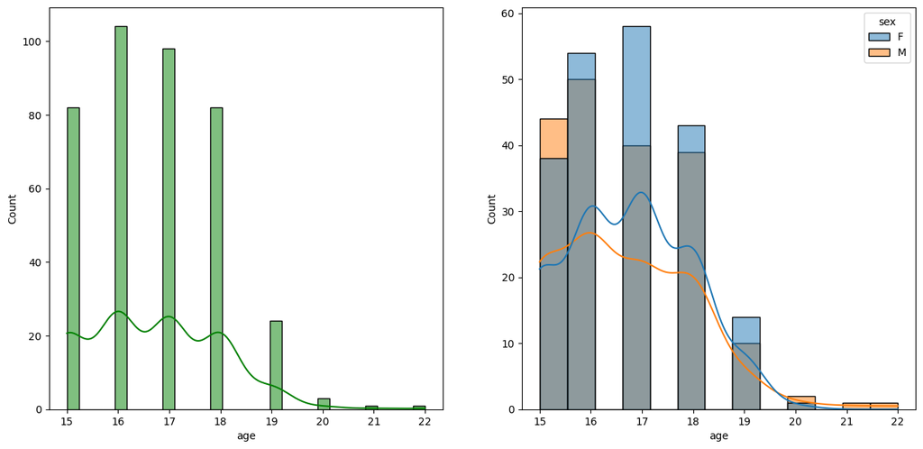

```python
fig, axs = plt.subplots(1, 2, figsize=(15, 7))
plt.subplot(121)
sns.histplot(data=student,x='age',bins=30,kde=True,color='g')
plt.subplot(122)
sns.histplot(data=student,x='age',kde=True,hue='sex')
plt.show()
```

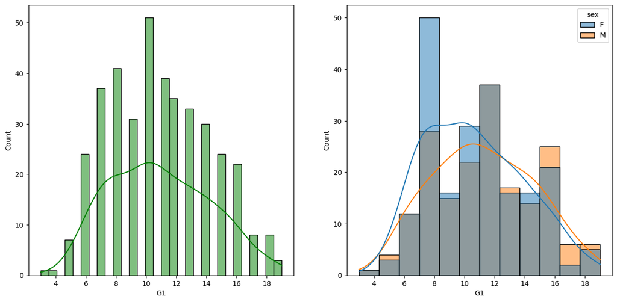

```python
fig, axs = plt.subplots(1, 2, figsize=(15, 7))
plt.subplot(121)
sns.histplot(data=student,x='G1',bins=30,kde=True,color='g')
plt.subplot(122)
sns.histplot(data=student,x='G1',kde=True,hue='sex')
plt.show()
```

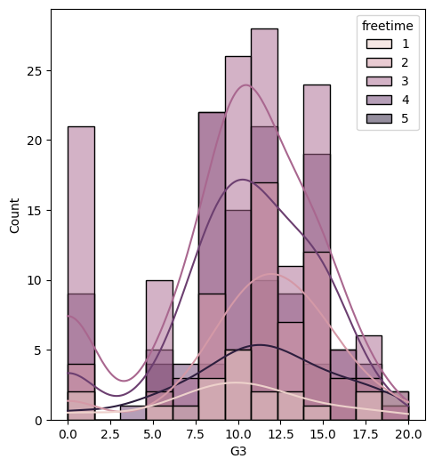

```python
plt.subplots(figsize=(25,6))
plt.subplot(141)
sns.histplot(data=student,x='G3',kde=True,hue='freetime')
```

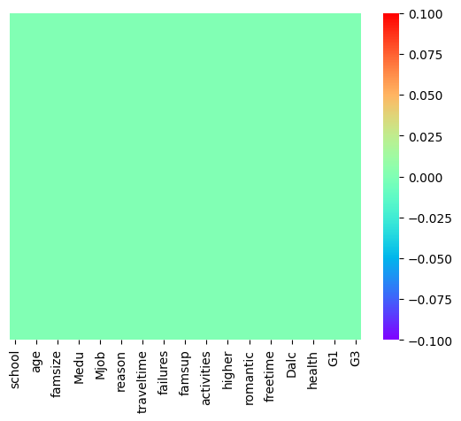

```python
sns.heatmap(student.isnull(),cmap="rainbow",yticklabels=False)
```

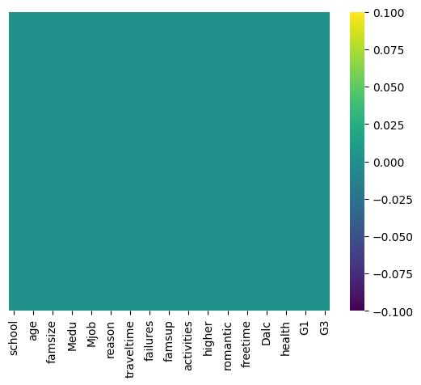

```python
sns.heatmap(student.isnull(),cmap="viridis",yticklabels=False)    # Map color - viridis
```

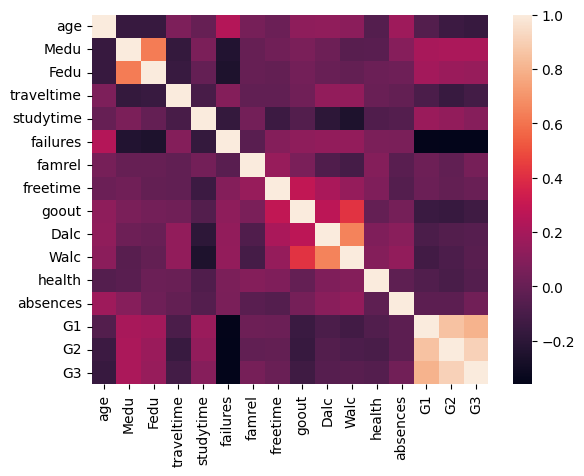

```python
corr=student.corr()
sns.heatmap(corr)
```

## Student's Sex

```python
f_student = len(student[student['sex'] == 'F'])    # Number of female students
print('Number of female students:',f_student)
m_student = len(student[student['sex'] == 'M'])    # Number of male students
print('Number of male students:',m_student)
```

```
Number of female students: 208
Number of male students: 187
```

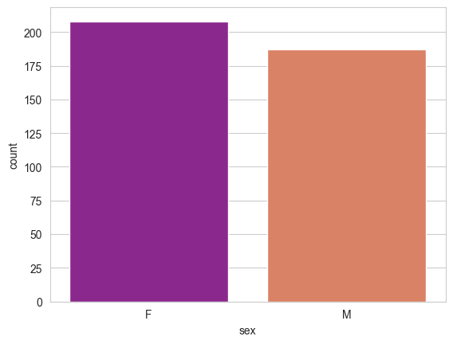

```python
sns.set_style('whitegrid')    # male & female student representaion on countplot
sns.countplot(x='sex',data=student,palette='plasma')
```

## Age of Student

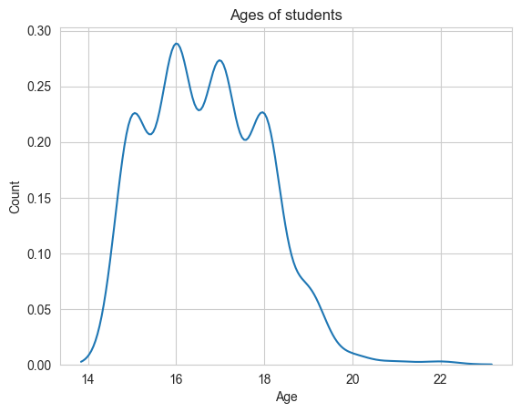

```python
b = sns.kdeplot(student['age'])    # Kernel Density Estimations
b.axes.set_title('Ages of students')
b.set_xlabel('Age')
b.set_ylabel('Count')
plt.show()
```

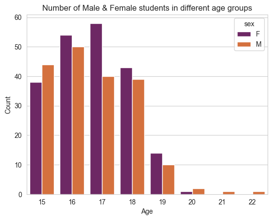

```python
b = sns.countplot(x='age',hue='sex', data=student, palette='inferno')
b.axes.set_title('Number of Male & Female students in different age groups')
b.set_xlabel("Age")
b.set_ylabel("Count")
plt.show()
```

- The student age seems to be ranging from 15-19, where gender distribution is pretty even in each age group.
- The age group above 19 may be outliers, year back students or droupouts.

```python
import cufflinks as cf
cf.go_offline()
```

```python
student.iplot()
```

[interactive chart not shown]

```python
student.iplot(kind='scatter',x='age',y='G3',mode='markers',size=8)    # Plot for age vs G3
```

[interactive chart not shown]

```python
student.iplot(kind='box')
```

[interactive chart not shown]

```python
student['G3'].iplot(kind='hist',bins=100,color='blue')
```

[interactive chart not shown]

## Student from Urban and Rural Area

```python
u_stud = len(student[student['address'] == 'U'])    # Number of urban areas students
print('Number of Urban students:',u_stud)
r_stud = len(student[student['address'] == 'R'])    # Number of rural areas students
print('Number of Rural students:',r_stud)
```

```
Number of Urban students: 307
Number of Rural students: 88
```

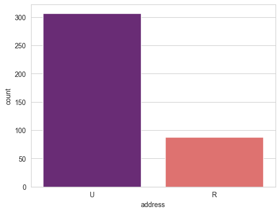

```python
sns.set_style('whitegrid')  # # urban & rural representaion on countplot
sns.countplot(x='address',data=student,palette='magma')
```

```
   . Approximately 77.72% students come from urban region and 22.28% from rural region.
```

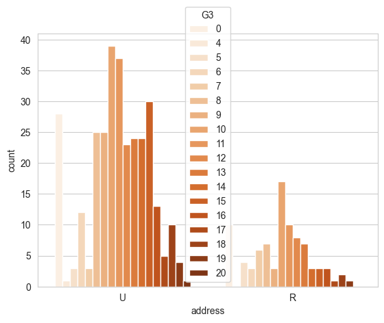

```python
sns.countplot(x='address',hue='G3',data=student,palette='Oranges')
```

## EDA - Exploratory Data Analysis

### 1. Does age affect final grade?

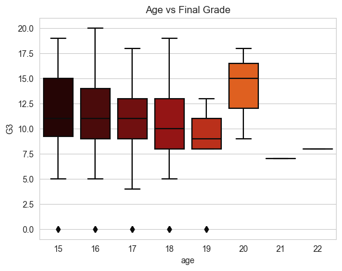

```python
b= sns.boxplot(x='age', y='G3',data=student,palette='gist_heat')
b.axes.set_title('Age vs Final Grade')
```

- Plotting the distribution rather than statistics would help us better understand the data
- The above plot shows that the median grades of the three age groups(15,16,17) are similar. Note the skewness of age group 19. (may be due to sample size). Age group 20 seems to score highest grades among all.

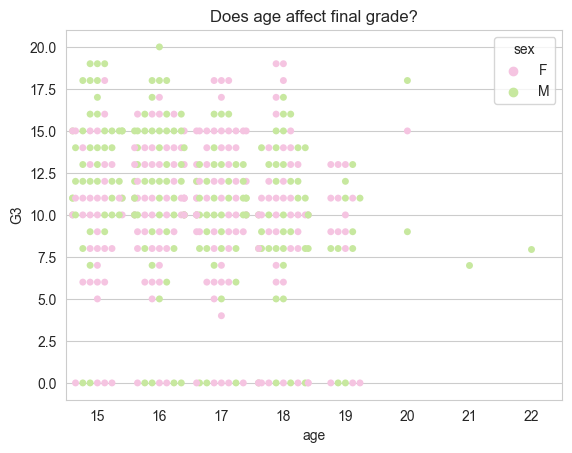

```python
b = sns.swarmplot(x='age', y='G3',hue='sex', data=student,palette='PiYG')
b.axes.set_title('Does age affect final grade?')
```

### 2. Do urban students perform better than rural students?

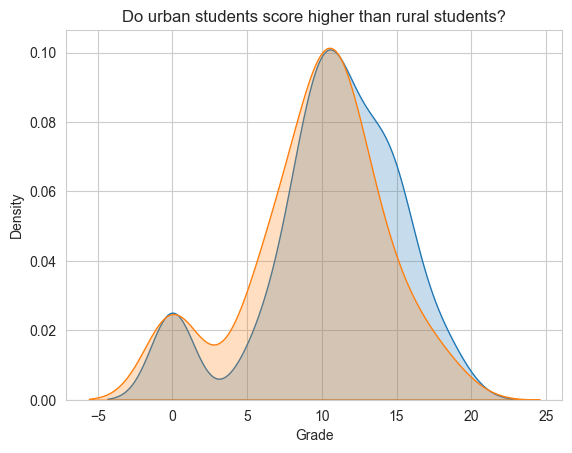

```python
# Grade distribution by address
sns.kdeplot(student.loc[student['address'] == 'U', 'G3'], label='Urban', shade = True)
sns.kdeplot(student.loc[student['address'] == 'R', 'G3'], label='Rural', shade = True)
plt.title('Do urban students score higher than rural students?')
plt.xlabel('Grade');
plt.ylabel('Density')
plt.show()
```

- The above graph clearly shows there is not much difference between the grades based on location.

```python
student.corr()['G3'].sort_values()
```

```
failures     -0.360415
age          -0.161579
goout        -0.132791
traveltime   -0.117142
health       -0.061335
Dalc         -0.054660
Walc         -0.051939
freetime      0.011307
absences      0.034247
famrel        0.051363
studytime     0.097820
Fedu          0.152457
Medu          0.217147
G1            0.801468
G2            0.904868
G3            1.000000
Name: G3, dtype: float64
```

### Multivariate analysis using pieplot

```
(-1.25, 1.25, -1.25, 1.25)
```

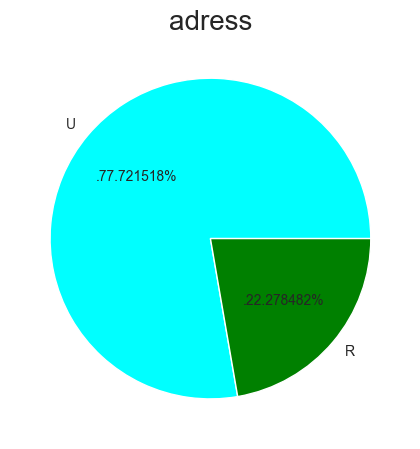

```python
plt.rcParams['figure.figsize'] = (30, 12)

plt.subplot(1, 5, 1)
size = student['address'].value_counts()
labels = 'U', 'R'
color = ['cyan','green']



plt.pie(size, colors = color, labels = labels,autopct = '.%2f%%')
plt.title('adress', fontsize = 20)
plt.axis('off')
```

```
(-1.25, 1.25, -1.25, 1.25)
```

[figure not shown]

```python
plt.subplot(1, 5, 2)
size = student['sex'].value_counts()

labels = 'M','F'

color = [ 'green', 'blue', 'cyan','orange']


plt.pie(size, colors = color,labels = labels,autopct = '.%2f%%')
plt.title('sex', fontsize = 20)
plt.axis('off')
```

### Feature Wise Visualization

#### SEX COLUMN

- How is distribution of sex ?
- Is gender has any impact on student's performance ?

#### UNIVARIATE ANALYSIS ( How is distribution of Sex ? )

[figure not shown]

```python
f,ax=plt.subplots(1,2,figsize=(20,10))
sns.countplot(x=student['sex'],data=student,palette ='bright',ax=ax[0],saturation=0.95)
for container in ax[0].containers:
    ax[0].bar_label(container,color='black',size=20)

plt.pie(x=student['sex'].value_counts(),labels=['M','F'],explode=[0,0.1],autopct='%1.1f%%',shadow=True,colors=['#ff4d4d','#ff8000'])
plt.show()
```

#### BIVARIATE ANALYSIS ( Is sex has any impact on student's performance ? )

```python
gender_group = student.groupby('sex').mean()
gender_group
```

| sex | age | Medu | Fedu | traveltime | studytime | failures | famrel | freetime | goout | Dalc | Walc | health | absences | G1 | G2 | G3 |
| --- | --- | --- | --- | --- | --- | --- | --- | --- | --- | --- | --- | --- | --- | --- | --- | --- |
| F | 16.730769 | 2.668269 | 2.485577 | 1.408654 | 2.278846 | 0.302885 | 3.894231 | 3.009615 | 3.028846 | 1.254808 | 1.956731 | 3.365385 | 6.216346 | 10.620192 | 10.389423 | 9.966346 |
| M | 16.657754 | 2.839572 | 2.561497 | 1.491979 | 1.764706 | 0.368984 | 4.000000 | 3.486631 | 3.197861 | 1.732620 | 2.663102 | 3.764706 | 5.144385 | 11.229947 | 11.074866 | 10.914439 |

```python
student
```

|  | school | sex | age | address | famsize | Pstatus | Medu | Fedu | Mjob | Fjob | ... | famrel | freetime | goout | Dalc | Walc | health | absences | G1 | G2 | G3 |
| --- | --- | --- | --- | --- | --- | --- | --- | --- | --- | --- | --- | --- | --- | --- | --- | --- | --- | --- | --- | --- | --- |
| 0 | GP | F | 18 | U | GT3 | A | 4 | 4 | at_home | teacher | ... | 4 | 3 | 4 | 1 | 1 | 3 | 6 | 5 | 6 | 6 |
| 1 | GP | F | 17 | U | GT3 | T | 1 | 1 | at_home | other | ... | 5 | 3 | 3 | 1 | 1 | 3 | 4 | 5 | 5 | 6 |
| 2 | GP | F | 15 | U | LE3 | T | 1 | 1 | at_home | other | ... | 4 | 3 | 2 | 2 | 3 | 3 | 10 | 7 | 8 | 10 |
| 3 | GP | F | 15 | U | GT3 | T | 4 | 2 | health | services | ... | 3 | 2 | 2 | 1 | 1 | 5 | 2 | 15 | 14 | 15 |
| 4 | GP | F | 16 | U | GT3 | T | 3 | 3 | other | other | ... | 4 | 3 | 2 | 1 | 2 | 5 | 4 | 6 | 10 | 10 |
| ... | ... | ... | ... | ... | ... | ... | ... | ... | ... | ... | ... | ... | ... | ... | ... | ... | ... | ... | ... | ... | ... |
| 390 | MS | M | 20 | U | LE3 | A | 2 | 2 | services | services | ... | 5 | 5 | 4 | 4 | 5 | 4 | 11 | 9 | 9 | 9 |
| 391 | MS | M | 17 | U | LE3 | T | 3 | 1 | services | services | ... | 2 | 4 | 5 | 3 | 4 | 2 | 3 | 14 | 16 | 16 |
| 392 | MS | M | 21 | R | GT3 | T | 1 | 1 | other | other | ... | 5 | 5 | 3 | 3 | 3 | 3 | 3 | 10 | 8 | 7 |
| 393 | MS | M | 18 | R | LE3 | T | 3 | 2 | services | other | ... | 4 | 4 | 1 | 3 | 4 | 5 | 0 | 11 | 12 | 10 |
| 394 | MS | M | 19 | U | LE3 | T | 1 | 1 | other | at_home | ... | 3 | 2 | 3 | 3 | 3 | 5 | 5 | 8 | 9 | 9 |

395 rows × 33 columns

# Encoding categorical variables using LabelEncoder()

```python
from sklearn.preprocessing import LabelEncoder
le=LabelEncoder()
```

```python
student.iloc[:,0]=le.fit_transform(student.iloc[:,0])
student.iloc[:,1]=le.fit_transform(student.iloc[:,1])
student.iloc[:,3]=le.fit_transform(student.iloc[:,3])
student.iloc[:,4]=le.fit_transform(student.iloc[:,4])
student.iloc[:,5]=le.fit_transform(student.iloc[:,5])
student.iloc[:,8]=le.fit_transform(student.iloc[:,8])
student.iloc[:,9]=le.fit_transform(student.iloc[:,9])
student.iloc[:,10]=le.fit_transform(student.iloc[:,10])
student.iloc[:,11]=le.fit_transform(student.iloc[:,11])
student.iloc[:,15]=le.fit_transform(student.iloc[:,15])
student.iloc[:,16]=le.fit_transform(student.iloc[:,16])
student.iloc[:,17]=le.fit_transform(student.iloc[:,17])
student.iloc[:,18]=le.fit_transform(student.iloc[:,18])
student.iloc[:,19]=le.fit_transform(student.iloc[:,19])
student.iloc[:,20]=le.fit_transform(student.iloc[:,20])
student.iloc[:,21]=le.fit_transform(student.iloc[:,21])
student.iloc[:,22]=le.fit_transform(student.iloc[:,22])
```

[output not shown]

[output cut: 12 more lines]

[output not shown]

```python
student.head()
```

|  | school | sex | age | address | famsize | Pstatus | Medu | Fedu | Mjob | Fjob | ... | famrel | freetime | goout | Dalc | Walc | health | absences | G1 | G2 | G3 |
| --- | --- | --- | --- | --- | --- | --- | --- | --- | --- | --- | --- | --- | --- | --- | --- | --- | --- | --- | --- | --- | --- |
| 0 | 0 | 0 | 18 | 1 | 0 | 0 | 4 | 4 | 0 | 4 | ... | 4 | 3 | 4 | 1 | 1 | 3 | 6 | 5 | 6 | 6 |
| 1 | 0 | 0 | 17 | 1 | 0 | 1 | 1 | 1 | 0 | 2 | ... | 5 | 3 | 3 | 1 | 1 | 3 | 4 | 5 | 5 | 6 |
| 2 | 0 | 0 | 15 | 1 | 1 | 1 | 1 | 1 | 0 | 2 | ... | 4 | 3 | 2 | 2 | 3 | 3 | 10 | 7 | 8 | 10 |
| 3 | 0 | 0 | 15 | 1 | 0 | 1 | 4 | 2 | 1 | 3 | ... | 3 | 2 | 2 | 1 | 1 | 5 | 2 | 15 | 14 | 15 |
| 4 | 0 | 0 | 16 | 1 | 0 | 1 | 3 | 3 | 2 | 2 | ... | 4 | 3 | 2 | 1 | 2 | 5 | 4 | 6 | 10 | 10 |

5 rows × 33 columns

```python
student.tail()
```

|  | school | sex | age | address | famsize | Pstatus | Medu | Fedu | Mjob | Fjob | ... | famrel | freetime | goout | Dalc | Walc | health | absences | G1 | G2 | G3 |
| --- | --- | --- | --- | --- | --- | --- | --- | --- | --- | --- | --- | --- | --- | --- | --- | --- | --- | --- | --- | --- | --- |
| 390 | 1 | 1 | 20 | 1 | 1 | 0 | 2 | 2 | 3 | 3 | ... | 5 | 5 | 4 | 4 | 5 | 4 | 11 | 9 | 9 | 9 |
| 391 | 1 | 1 | 17 | 1 | 1 | 1 | 3 | 1 | 3 | 3 | ... | 2 | 4 | 5 | 3 | 4 | 2 | 3 | 14 | 16 | 16 |
| 392 | 1 | 1 | 21 | 0 | 0 | 1 | 1 | 1 | 2 | 2 | ... | 5 | 5 | 3 | 3 | 3 | 3 | 3 | 10 | 8 | 7 |
| 393 | 1 | 1 | 18 | 0 | 1 | 1 | 3 | 2 | 3 | 2 | ... | 4 | 4 | 1 | 3 | 4 | 5 | 0 | 11 | 12 | 10 |
| 394 | 1 | 1 | 19 | 1 | 1 | 1 | 1 | 1 | 2 | 0 | ... | 3 | 2 | 3 | 3 | 3 | 5 | 5 | 8 | 9 | 9 |

5 rows × 33 columns

```python
student.corr()['G3'].sort_values()    # Correlation wrt G3
```

```
failures     -0.360415
age          -0.161579
goout        -0.132791
romantic     -0.129970
traveltime   -0.117142
schoolsup    -0.082788
guardian     -0.070109
health       -0.061335
Pstatus      -0.058009
Dalc         -0.054660
Walc         -0.051939
school       -0.045017
famsup       -0.039157
freetime      0.011307
activities    0.016100
absences      0.034247
Fjob          0.042286
famrel        0.051363
nursery       0.051568
famsize       0.081407
studytime     0.097820
internet      0.098483
paid          0.101996
Mjob          0.102082
sex           0.103456
address       0.105756
reason        0.121994
Fedu          0.152457
higher        0.182465
Medu          0.217147
G1            0.801468
G2            0.904868
G3            1.000000
Name: G3, dtype: float64
```

```python
# drop the school and grade columns
stud = student.drop(['school', 'G1', 'G2'], axis='columns')
```

```python
stud
```

|  | sex | age | address | famsize | Pstatus | Medu | Fedu | Mjob | Fjob | reason | ... | internet | romantic | famrel | freetime | goout | Dalc | Walc | health | absences | G3 |
| --- | --- | --- | --- | --- | --- | --- | --- | --- | --- | --- | --- | --- | --- | --- | --- | --- | --- | --- | --- | --- | --- |
| 0 | 0 | 18 | 1 | 0 | 0 | 4 | 4 | 0 | 4 | 0 | ... | 0 | 0 | 4 | 3 | 4 | 1 | 1 | 3 | 6 | 6 |
| 1 | 0 | 17 | 1 | 0 | 1 | 1 | 1 | 0 | 2 | 0 | ... | 1 | 0 | 5 | 3 | 3 | 1 | 1 | 3 | 4 | 6 |
| 2 | 0 | 15 | 1 | 1 | 1 | 1 | 1 | 0 | 2 | 2 | ... | 1 | 0 | 4 | 3 | 2 | 2 | 3 | 3 | 10 | 10 |
| 3 | 0 | 15 | 1 | 0 | 1 | 4 | 2 | 1 | 3 | 1 | ... | 1 | 1 | 3 | 2 | 2 | 1 | 1 | 5 | 2 | 15 |
| 4 | 0 | 16 | 1 | 0 | 1 | 3 | 3 | 2 | 2 | 1 | ... | 0 | 0 | 4 | 3 | 2 | 1 | 2 | 5 | 4 | 10 |
| ... | ... | ... | ... | ... | ... | ... | ... | ... | ... | ... | ... | ... | ... | ... | ... | ... | ... | ... | ... | ... | ... |
| 390 | 1 | 20 | 1 | 1 | 0 | 2 | 2 | 3 | 3 | 0 | ... | 0 | 0 | 5 | 5 | 4 | 4 | 5 | 4 | 11 | 9 |
| 391 | 1 | 17 | 1 | 1 | 1 | 3 | 1 | 3 | 3 | 0 | ... | 1 | 0 | 2 | 4 | 5 | 3 | 4 | 2 | 3 | 16 |
| 392 | 1 | 21 | 0 | 0 | 1 | 1 | 1 | 2 | 2 | 0 | ... | 0 | 0 | 5 | 5 | 3 | 3 | 3 | 3 | 3 | 7 |
| 393 | 1 | 18 | 0 | 1 | 1 | 3 | 2 | 3 | 2 | 0 | ... | 1 | 0 | 4 | 4 | 1 | 3 | 4 | 5 | 0 | 10 |
| 394 | 1 | 19 | 1 | 1 | 1 | 1 | 1 | 2 | 0 | 0 | ... | 1 | 0 | 3 | 2 | 3 | 3 | 3 | 5 | 5 | 9 |

395 rows × 30 columns

. Although G1 and G2 which are period grades of a student and are highly correlated to the final grade G3, we drop them. It is more difficult to predict G3 without G2 and G1, but such prediction is much more useful because we want to find other factors affect the grade.

```python
# Find correlations with the Grade

most_correlated = stud.corr().abs()['G3'].sort_values(ascending=False)

# Maintain the top 8 most correlation features with Grade

most_correlated = most_correlated[:9]
most_correlated
```

```
G3          1.000000
failures    0.360415
Medu        0.217147
higher      0.182465
age         0.161579
Fedu        0.152457
goout       0.132791
romantic    0.129970
reason      0.121994
Name: G3, dtype: float64
```

```python
stud = stud.loc[:, most_correlated.index]
stud.head()
```

|  | G3 | failures | Medu | higher | age | Fedu | goout | romantic | reason |
| --- | --- | --- | --- | --- | --- | --- | --- | --- | --- |
| 0 | 6 | 0 | 4 | 1 | 18 | 4 | 4 | 0 | 0 |
| 1 | 6 | 0 | 1 | 1 | 17 | 1 | 3 | 0 | 0 |
| 2 | 10 | 3 | 1 | 1 | 15 | 1 | 2 | 0 | 2 |
| 3 | 15 | 0 | 4 | 1 | 15 | 2 | 2 | 1 | 1 |
| 4 | 10 | 0 | 3 | 1 | 16 | 3 | 2 | 0 | 1 |

# Failure Attribute

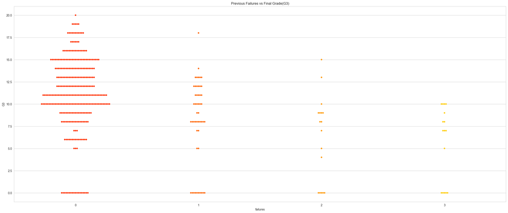

```python
b = sns.swarmplot(x=stud['failures'],y=stud['G3'],palette='autumn')
b.axes.set_title('Previous Failures vs Final Grade(G3)')
```

**Observation :** Student with less previous failures usually score higher

### Family Education Attribute ( Fedu + Medu )

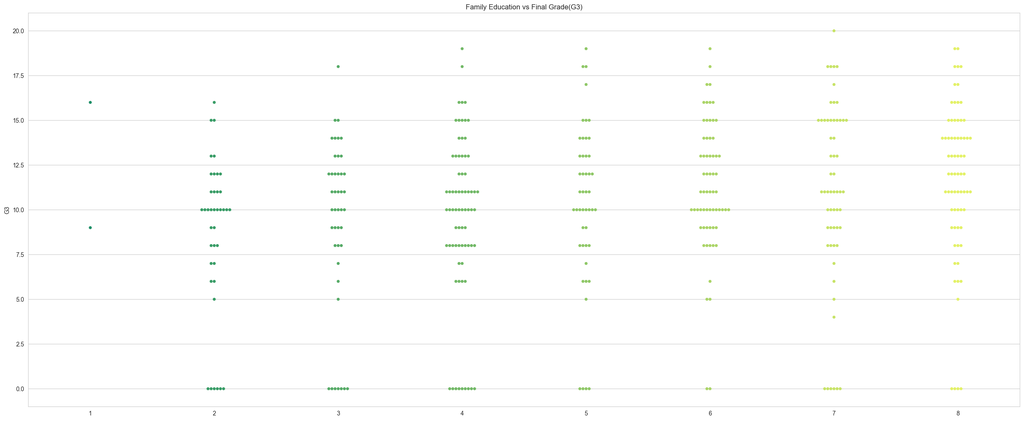

```python
fa_edu = stud['Fedu'] + stud['Medu']
b = sns.swarmplot(x=fa_edu,y=stud['G3'],palette='summer')
b.axes.set_title('Family Education vs Final Grade(G3)')
```

**Observation :** Educated families result in higher grades

## Wish to go for Higher Education Attribute

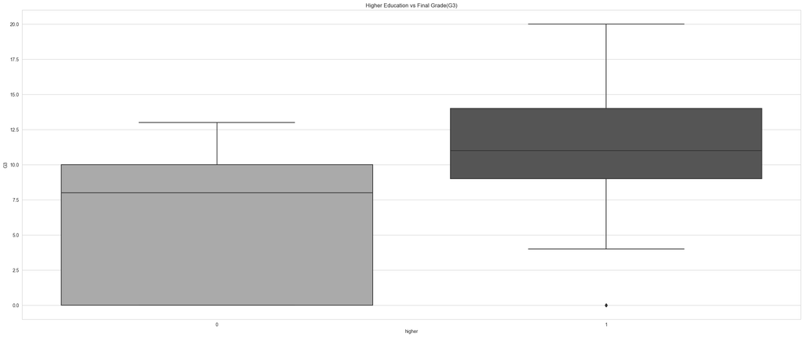

```python
b = sns.boxplot(x=stud['higher'],y=stud['G3'],palette='binary')
b.axes.set_title('Higher Education vs Final Grade(G3)')
```

## Going Out with Friends Attribute

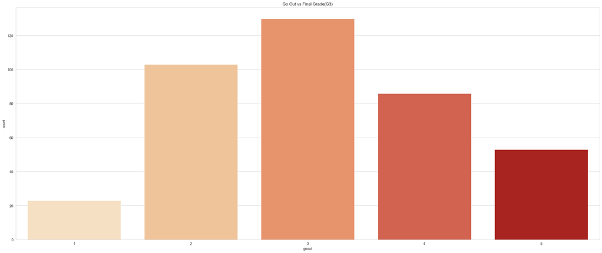

```python
b = sns.countplot(x=stud['goout'],palette='OrRd')
b.axes.set_title('Go Out vs Final Grade(G3)')
```

**Observation :** The students have an average score when it comes to going out with friends.

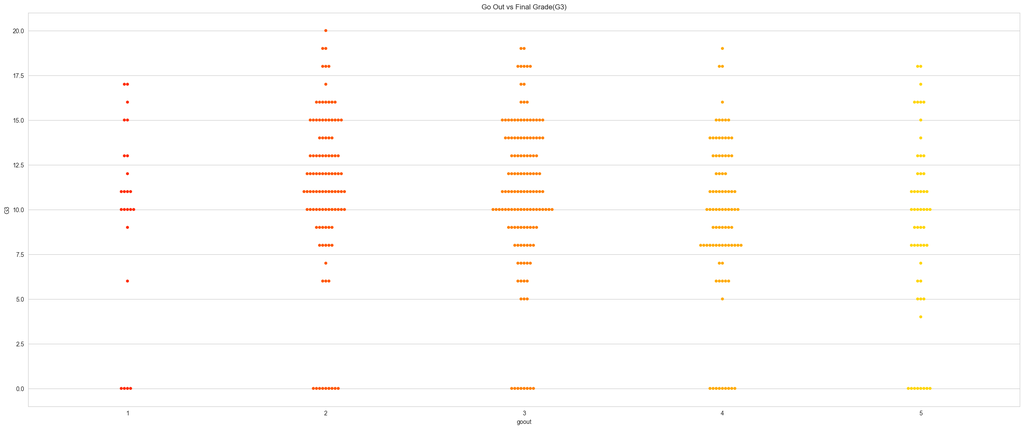

```python
b = sns.swarmplot(x=stud['goout'],y=stud['G3'],palette='autumn')
b.axes.set_title('Go Out vs Final Grade(G3)')
```

**Observation :** Students who go out a lot score less

## Romantic relationship Attribute

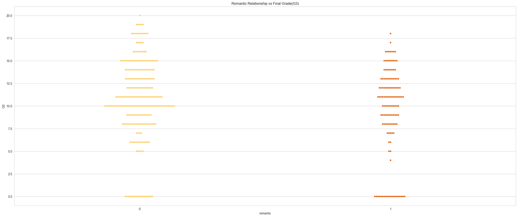

```python
b = sns.swarmplot(x=stud['romantic'],y=stud['G3'],palette='YlOrBr')
b.axes.set_title('Romantic Relationship vs Final Grade(G3)')
```

- Here romantic attribute with value 0 means no relationship and value with 1 means in relationship

**Observation :** Students with no romantic relationship score higher

## Reason Attribute

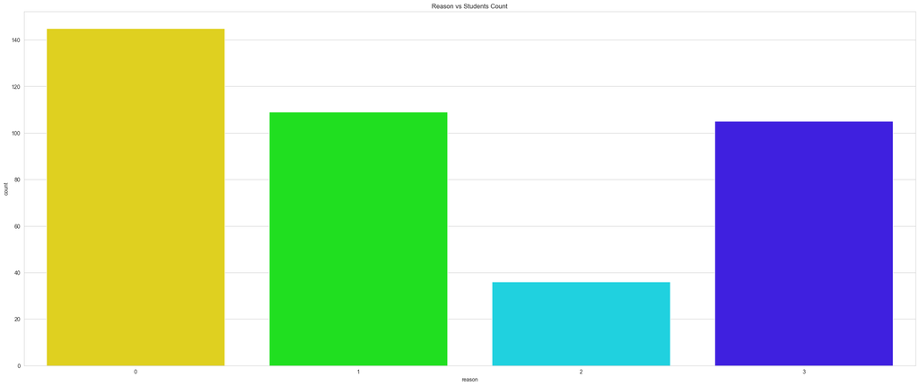

```python
b = sns.countplot(x='reason',data=stud,palette='gist_rainbow')    # Reason to choose this school
b.axes.set_title('Reason vs Students Count')
```

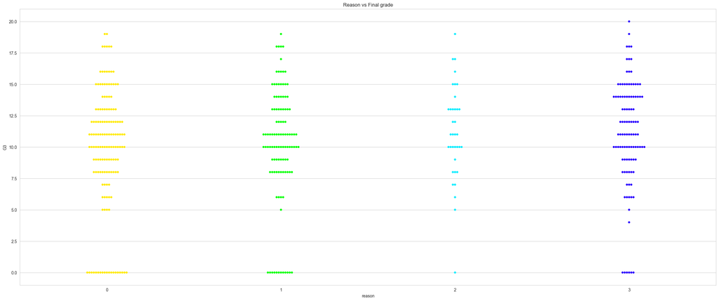

```python
b = sns.swarmplot(x='reason', y='G3', data=stud,palette='gist_rainbow')
b.axes.set_title('Reason vs Final grade')
```

**Observation :** The students have an equally distributed average score when it comes to reason attribute.

## Machine learning Algorithm

```python
# Standard ML Models for comparison


from sklearn.linear_model import LinearRegression
from sklearn.linear_model import ElasticNet
from sklearn.ensemble import RandomForestRegressor
from sklearn.ensemble import ExtraTreesRegressor
from sklearn.ensemble import GradientBoostingRegressor
from sklearn.svm import SVR
```

```python
# Splitting data into training/testing

from sklearn.model_selection import train_test_split
from sklearn.preprocessing import MinMaxScaler
```

```python
# Metrics

from sklearn.metrics import mean_squared_error, mean_absolute_error, median_absolute_error

# Distributions

import scipy
```

```python
# splitting the data into training and testing data (75% and 25%)
# we mention the random state to achieve the same split everytime we run the code

X_train, X_test, y_train, y_test = train_test_split(stud, stud['G3'], test_size = 0.25, random_state=42)
```

```python
X_train.head()
```

|  | G3 | failures | Medu | higher | age | Fedu | goout | romantic | reason |
| --- | --- | --- | --- | --- | --- | --- | --- | --- | --- |
| 16 | 14 | 0 | 4 | 1 | 16 | 4 | 3 | 0 | 3 |
| 66 | 12 | 0 | 4 | 1 | 15 | 4 | 3 | 1 | 3 |
| 211 | 13 | 0 | 4 | 1 | 17 | 4 | 5 | 1 | 1 |
| 7 | 6 | 0 | 4 | 1 | 17 | 4 | 4 | 0 | 1 |
| 19 | 10 | 0 | 4 | 1 | 16 | 3 | 3 | 0 | 1 |

```python
y_train.head()
```

```
16     14
66     12
211    13
7       6
19     10
Name: G3, dtype: int64
```

```python
X_test.head()
```

|  | G3 | failures | Medu | higher | age | Fedu | goout | romantic | reason |
| --- | --- | --- | --- | --- | --- | --- | --- | --- | --- |
| 78 | 10 | 3 | 2 | 0 | 17 | 1 | 1 | 0 | 1 |
| 371 | 12 | 0 | 1 | 0 | 18 | 2 | 3 | 1 | 2 |
| 248 | 5 | 1 | 3 | 1 | 18 | 3 | 3 | 1 | 0 |
| 55 | 10 | 0 | 2 | 1 | 16 | 1 | 4 | 1 | 2 |
| 390 | 9 | 2 | 2 | 1 | 20 | 2 | 4 | 0 | 0 |

```python
y_test.head()
```

```
78     10
371    12
248     5
55     10
390     9
Name: G3, dtype: int64
```

## MAE - Mean Absolute Error & RMSE - Root Mean Square Error

```python
#  Calculate mae and  rmse

def evaluate_predictions(prediction,true):
    mae=np.mean(abs(predictions - true))
    rmse=np.sqrt(np.mean((prediction-true)**2))

    return mae,rmse
```

```python
# find the median

median_pred = X_train['G3'].median()
```

```python
median_pred
```

```
11.0
```

```python
# create a list with all values as median

median_preds = [median_pred for _ in range(len(X_test))]
```

```python
median_preds
```

[output not shown]

[output cut: 44 more lines]

```
 11.0,
 11.0,
 11.0,
 11.0,
 11.0,
 11.0,
 11.0,
 11.0,
 11.0,
 11.0,
 11.0,
 11.0,
 11.0,
 11.0,
 11.0]
```

```python
# store the true G3 values for passing into the function

true = X_test['G3']
```

```python
true
```

```
78     10
371    12
248     5
55     10
390     9
       ..
367     0
210     8
75     10
104    18
374    19
Name: G3, Length: 99, dtype: int64
```

```python
# Evaluate several ml models by training on training set and testing on testing set


def evaluate(X_train, X_test, y_train, y_test):

    # Names of models

    model_name_list = ['Linear Regression', 'ElasticNet Regression',
                      'Random Forest', 'Extra Trees', 'SVM',
                       'Gradient Boosted', 'Baseline']
    X_train = X_train.drop('G3', axis='columns')
    X_test = X_test.drop('G3', axis='columns')

    # Instantiate the models

    model1 = LinearRegression()
    model2 = ElasticNet(alpha=1.0, l1_ratio=0.5)
    model3 = RandomForestRegressor(n_estimators=100)
    model4 = ExtraTreesRegressor(n_estimators=100)
    model5 = SVR(kernel='rbf', degree=3, C=1.0, gamma='auto')
    model6 = GradientBoostingRegressor(n_estimators=50)

    # Dataframe for results

    results = pd.DataFrame(columns=['mae', 'rmse'], index = model_name_list)

    # Train and predict with each model

    for i, model in enumerate([model1, model2, model3, model4, model5, model6]):
        model.fit(X_train, y_train)
        predictions = model.predict(X_test)

        # Metrics

        mae = np.mean(abs(predictions - y_test))
        rmse = np.sqrt(np.mean((predictions - y_test) ** 2))

        # Insert results into the dataframe

        model_name = model_name_list[i]
        results.loc[model_name, :] = [mae, rmse]

    # Median Value Baseline Metrics

    baseline = np.median(y_train)
    baseline_mae = np.mean(abs(baseline - y_test))
    baseline_rmse = np.sqrt(np.mean((baseline - y_test) ** 2))

    results.loc['Baseline', :] = [baseline_mae, baseline_rmse]

    return results
```

```python
results=evaluate(X_train,X_test,y_train,y_test)
```

```python
results
```

|  | mae | rmse |
| --- | --- | --- |
| Linear Regression | 3.485115 | 4.432597 |
| ElasticNet Regression | 3.608051 | 4.573274 |
| Random Forest | 3.727265 | 4.671392 |
| Extra Trees | 3.752172 | 4.794294 |
| SVM | 3.549266 | 4.581466 |
| Gradient Boosted | 3.572105 | 4.500541 |
| Baseline | 3.787879 | 4.825228 |

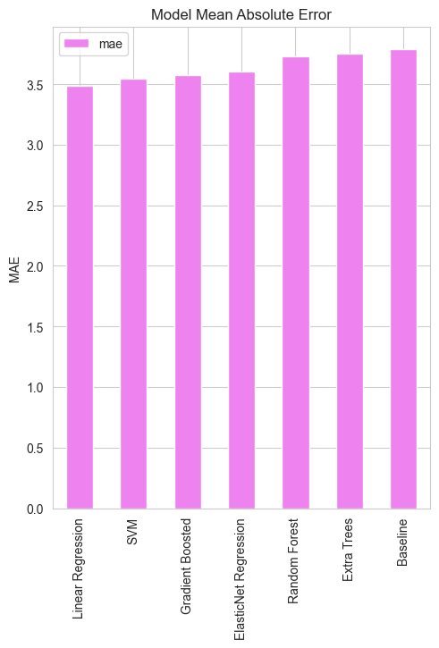

```python
plt.figure(figsize=(12, 7))

# Root mean squared error

ax =  plt.subplot(1, 2, 1)
results.sort_values('mae', ascending = True).plot.bar(y = 'mae', color = 'violet', ax = ax)
plt.title('Model Mean Absolute Error')
plt.ylabel('MAE')
```

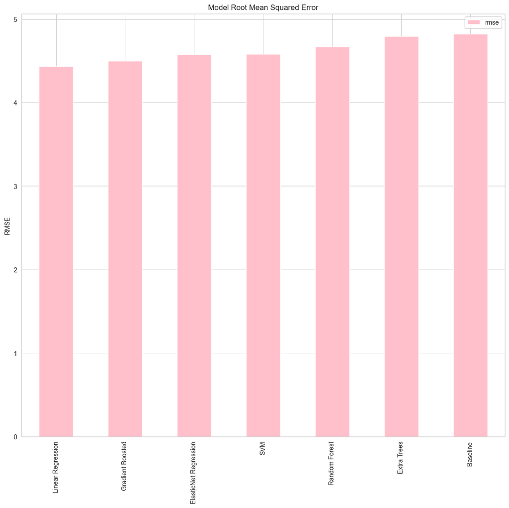

```python
# Median absolute percentage error

ax = plt.subplot(1, 2, 2)
results.sort_values('rmse', ascending = True).plot.bar(y = 'rmse', color = 'pink', ax = ax)
plt.title('Model Root Mean Squared Error')
plt.ylabel('RMSE')

plt.show()
```

**Conclusion:** As we see both Model Mean Absolute Error & Model Root Mean Squared Error that the linear regression is performing the best in both cases